# Red state, blue state: The polarizing influence of color in political maps. *Planned analyses for Stage 1 Registered Report*

Rémy A. Furrer, Adrienne Wood, Gary Lupyan, Karen Schloss, & Paula M. Niedenthal

5/11/2020

# Task 1 data synthesis

### Study design

|  | Red/blue | Yellow/green | No color |
| --- | --- | --- | --- |
| **Dichotomous** | redBlueDich | yellowGreenDich | grey |
| **Continuous** | redBlueCont | yellowGreenCont |  |

### Key parameters to update as study design changes

- **nParticipants**: Simulated sample size
- **allStates**: U.S. states included in task
- **allColorConditions**: Experimental conditions
- **conditionDiffsMeans**: *Relevant for data synthesis only*. How different should the color 1 and color 2 means of states be (on a 1-100 percentage scale)? A value of “5” means each group of states should will be +/- 5 points from the midpoint, aka the groups will be 10 points apart
- **conditionSDs**: *Relevant for data synthesis only*. How varied should the color 1 and color 2 states be (within color, again on a 1-100 percentage scale)?

```r
#### DEFINE KEY PARAMETERS HERE ####
nParticipants=400 #set desired sample size
allStates = c("Colorado","Florida","Nevada","NorthCarolina","Wisconsin","Ohio","NewHampshire","Pennsylvania") #define the possible states
allColorConditions =c("yellowGreenDich","yellowGreenCont",
                      "redBlueDich","redBlueCont","grey") # what are the conditions?
conditionDiffsMeans=c(5,5,10,7,0) # what should the effect of each condition be on the mean?
conditionSDs = c(4,7,4,7,4) # what should the effect of each condition be on the SD?

#### Synthesize dataset ####
colorConditionNums=seq(1,length(allColorConditions),by=1) # how many conditions are there?

df <- data.frame(subID=c(1:nParticipants)) # initial dataframe with subject IDs

for(participant in df$subID){ #loop through the IDs

  #assign a color condition
  thisCondNum <-sample(colorConditionNums,size=1)
  df[participant,"colorCond"]<-allColorConditions[thisCondNum]

  # assign the 4 states that get color1
  # (e.g., if condition is "yellowGreen", then color1 states are yellow)
  fourStates <-sample(allStates,size=4,replace=F)
  df[participant,"color1states"] <- paste(fourStates, sep="_", collapse="_")

  # create a DV column for each of the 8 states and generate random response
  # on our DV (which is percent of voters in that state)
  for(state in allStates){
    if(state %in% fourStates){
      # if the state is assigned to color 1, arbitrarily make it a lower-scored state
      thisVal <- as.integer(rnorm(1,mean=(50-conditionDiffsMeans[thisCondNum]),
                                  sd=conditionSDs))
    }
    else{
      # if the state is assigned to color 2, make it a higher-scored state
     thisVal <- as.integer(rnorm(1,mean=(50+conditionDiffsMeans[thisCondNum]),
                                  sd=conditionSDs))
    }
      df[participant,state] <-thisVal
  }
}
```

### Synthetic data

```r
DT::datatable(df, caption="Synthetic Task 1 Data")
```

|  | subID | colorCond | color1states | Colorado | Florida | Nevada | NorthCarolina | Wisconsin | Ohio | NewHampshire | Pennsylvania |
| --- | --- | --- | --- | --- | --- | --- | --- | --- | --- | --- | --- |
| 1 | 1 | grey | Ohio_Pennsylvania_NorthCarolina_Florida | 51 | 46 | 51 | 50 | 55 | 48 | 47 | 52 |
| 2 | 2 | redBlueDich | Pennsylvania_NorthCarolina_Colorado_NewHampshire | 41 | 62 | 55 | 45 | 48 | 54 | 39 | 38 |
| 3 | 3 | redBlueCont | Nevada_Wisconsin_Ohio_Pennsylvania | 55 | 57 | 46 | 56 | 48 | 39 | 48 | 39 |
| 4 | 4 | redBlueCont | Ohio_NewHampshire_Wisconsin_Nevada | 54 | 62 | 41 | 60 | 49 | 47 | 51 | 57 |
| 5 | 5 | redBlueCont | NorthCarolina_Pennsylvania_Wisconsin_NewHampshire | 59 | 52 | 57 | 42 | 37 | 57 | 44 | 45 |
| 6 | 6 | yellowGreenCont | Florida_Wisconsin_Ohio_NorthCarolina | 56 | 42 | 52 | 50 | 43 | 46 | 60 | 55 |
| 7 | 7 | yellowGreenCont | Ohio_Colorado_Florida_Nevada | 45 | 43 | 45 | 59 | 49 | 47 | 57 | 61 |
| 8 | 8 | redBlueDich | Wisconsin_NewHampshire_Pennsylvania_Ohio | 61 | 63 | 65 | 57 | 42 | 47 | 44 | 31 |
| 9 | 9 | yellowGreenDich | Wisconsin_Ohio_Nevada_Florida | 56 | 50 | 42 | 57 | 47 | 44 | 57 | 51 |
| 10 | 10 | yellowGreenCont | NorthCarolina_Florida_Colorado_Nevada | 43 | 44 | 53 | 40 | 59 | 53 | 58 | 55 |

[output cut: 390 more lines]

## Density plots of participants’ responses by condition

First convert dataframe to long format and center responses within-participant for plotting purposes

Then plot

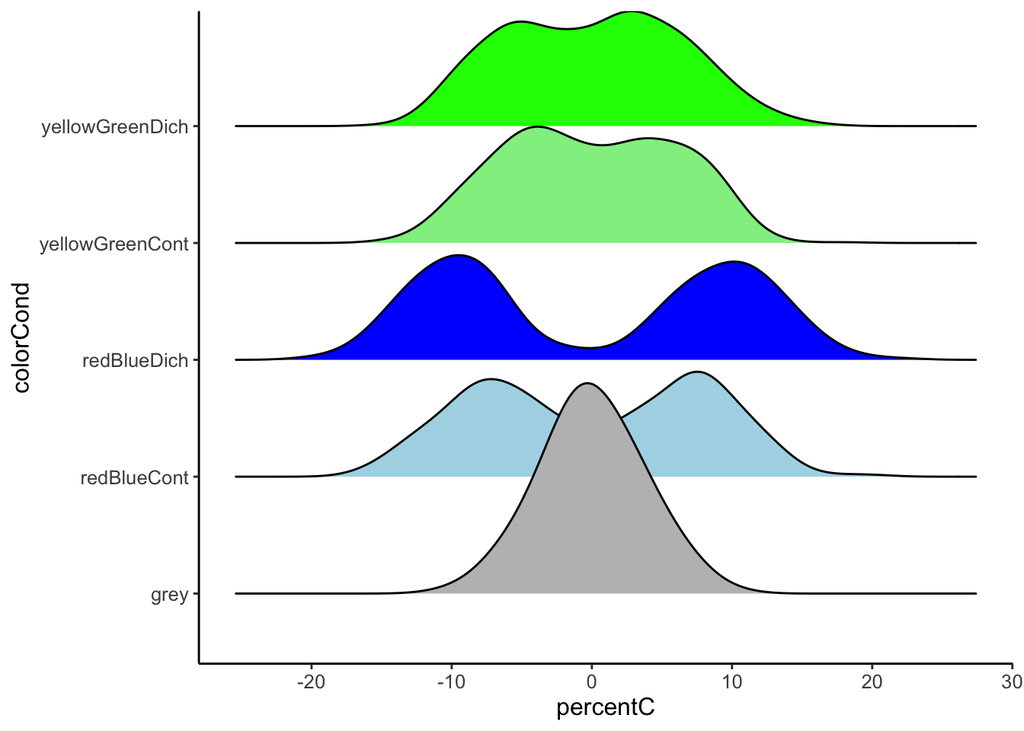

```r
plot <-ggplot(dfL,aes(x=percentC,y=colorCond,fill=colorCond))+
    ggridges::stat_density_ridges()+
    scale_fill_manual(values=rev(c("green","light green", "blue", "light blue", "grey")))+
    theme(text=element_text(size=12),
        legend.position="none",panel.grid.major = element_blank(),
        panel.grid.minor = element_blank(),
        panel.background = element_blank(),
        axis.line = element_line(colour = "black"))


plot
```

# Task 1 analyses

## Calculate each participant’s F statistic

Each participant judged the political leaning of 8 states that were randomly assigned to one of two color-coded groups. We want to know the ratio of the Sum of Squares Between groups (SSB, which is how differently the participant judged the two groups’ political leanings to be) to the Sum of Squares Within groups (SSW, which is how much variance the participant’s responses had for each of the two groups).

In other words, we want to calculate an **ANOVA** for each participant and use the resulting F statistic as our index of that participant’s estimate of how different the two groups’ politics are.

```r
for(participant in df$subID){
  partdf <-data.frame("color"=NA,"value"=NA) #create an empty df for this subject
  for(state in allStates){ #loop through all 8 states

    #if the state is in this participant's "color1" variable, add it to the
    #participant's df with color=1 and value=the participant's response.
    if(grepl(state, df[df$subID==participant,"color1states"], fixed=TRUE)){
      partdf <- rbind(partdf,data.frame("color"=1,"value"=df[df$subID==participant,state]))
    #if the state isn't in this participant's "color1" variable, add it to the
    #participant's df with color=2 and value=the participant's repsonse.
    }
    else{
      partdf <- rbind(partdf,data.frame("color"=2,"value"=df[df$subID==participant,state]))
    }
  }
  # calculate the participant's F score and add it to our original dataframe,
  # along with SSW and SSB
  partAnovaSummary <-summary(aov(value~color,partdf))
  df[df$subID==participant,"SSB"]<-partAnovaSummary[[1]][2][1,'Sum Sq']
  df[df$subID==participant,"SSW"]<-partAnovaSummary[[1]][2][2,'Sum Sq']
  df[df$subID==participant,"Fvalue"]<-partAnovaSummary[[1]][4][1,'F value']
}
```

## Main analyses for Task 1

Do red/blue, yellow/green, and no color differ from each other? Our primary analyses are with participants’ **F values** (ratio of SSB/SSW) as the outcome variable, but secondary analyses will use **SSB** and **SSW** to clarify what type of polarization, if any, we’re getting.

**Note on model assumptions**: We need to log-transform the synthesized Fvalue, SSB, and SSW outcome variables because they are overdispersed and have positive skew. This mostly corrects for non-normally distributed residuals, but note that the log(Fvalue+1) variable still has some non-normalcy due to F values having an asymptote at 0. **With the real data,** we will check for model assumptions using the modelAssumptions() function from the lmSupport package and may transform/alter the variables/model accordingly, using the MASS::boxcox() function to help determine the appropriate Lamda. If it is <1, we will see if log(var+1) achieves normality.

```r
df$FvalueLog <-log(df$Fvalue+1)
df$SSBLog <-log(df$SSB+1)
df$SSWLog <-log(df$SSW+1)
```

**!! I’m not sure of the best way to treat the no color condition in these analyses!! What’s a reasonable model that would include all the data at once?** Keep in mind the 2*3-ish design with an empty cell. We could consider using the No Color condition responses as the “null model” distribution and see if the distributions of the other conditions differ from it.

```r
# create a gradient variable
df$colorGradient <-ifelse(grepl("Dich", df$colorCond, fixed=TRUE),"dichotomous",
                        ifelse(grepl("Cont", df$colorCond,
                                             fixed=TRUE),"continuous","grey"))

# create a LINEAR color scheme variable
df$colorLinear <-ifelse(grepl("redBlue", df$colorCond, fixed=TRUE),.5,
                        ifelse(grepl("yellowGreen", df$colorCond, fixed=TRUE),0,-.5))
# make a version of the LINEAR scheme for analyses that don't include the no color condition
df$colorLinear2 <-ifelse(grepl("redBlue", df$colorCond, fixed=TRUE),.5,
                        ifelse(grepl("yellowGreen", df$colorCond,
                                     fixed=TRUE),-.5,NA))

# create an ORTHOGONAL color scheme variable
df$colorOrthogonal <-ifelse(grepl("redBlue", df$colorCond, fixed=TRUE),-1.0/3.0,
                        ifelse(grepl("yellowGreen", df$colorCond, fixed=TRUE),
                               2.0/3.0,-1.0/3.0))
```

### Effect of color scheme, excluding the continuous gradient conditions

For now, I’m excluding the continuous gradient data from these analyses because the “no color” condition doesn’t have an equivalent gradient manipulation.

#### Effect of color scheme on F values, dichotomous colors only

```r
modFcolor <-lm(FvalueLog~colorLinear+colorOrthogonal,data=df[df$colorGradient!="continuous",])
summary(modFcolor)
```

```
##
## Call:
## lm(formula = FvalueLog ~ colorLinear + colorOrthogonal, data = df[df$colorGradient !=
##     "continuous", ])
##
## Residuals:
##      Min       1Q   Median       3Q      Max
## -2.13091 -0.57491 -0.06026  0.47621  2.12159
##
## Coefficients:
##                 Estimate Std. Error t value Pr(>|t|)
## (Intercept)      2.50426    0.04987  50.214   <2e-16 ***
## colorLinear      3.30940    0.12050  27.464   <2e-16 ***
## colorOrthogonal  0.26099    0.10722   2.434   0.0157 *
## ---
## Signif. codes:  0 '***' 0.001 '**' 0.01 '*' 0.05 '.' 0.1 ' ' 1
##
## Residual standard error: 0.768 on 235 degrees of freedom
## Multiple R-squared:  0.765,  Adjusted R-squared:  0.763
## F-statistic: 382.5 on 2 and 235 DF,  p-value: < 2.2e-16
```

#### Effect of color scheme on Sum of Squares Within, dichotomous colors only

```r
modSSWcolor<-lm(SSWLog~colorLinear+colorOrthogonal,data=df[df$colorGradient!="continuous",])
summary(modSSWcolor)
```

```
##
## Call:
## lm(formula = SSWLog ~ colorLinear + colorOrthogonal, data = df[df$colorGradient !=
##     "continuous", ])
##
## Residuals:
##      Min       1Q   Median       3Q      Max
## -1.74408 -0.36577  0.09467  0.40131  1.29436
##
## Coefficients:
##                 Estimate Std. Error t value Pr(>|t|)
## (Intercept)      4.38247    0.04124 106.261   <2e-16 ***
## colorLinear      0.02741    0.09965   0.275    0.784
## colorOrthogonal  0.01094    0.08866   0.123    0.902
## ---
## Signif. codes:  0 '***' 0.001 '**' 0.01 '*' 0.05 '.' 0.1 ' ' 1
##
## Residual standard error: 0.6351 on 235 degrees of freedom
## Multiple R-squared:  0.000396,   Adjusted R-squared:  -0.008111
## F-statistic: 0.04654 on 2 and 235 DF,  p-value: 0.9545
```

#### Effect of color scheme on Sum of Squares Between

```r
modSSBcolor<-lm(SSBLog~colorLinear+colorOrthogonal,data=df[df$colorGradient!="continuous",])
summary(modSSBcolor)
```

```
##
## Call:
## lm(formula = SSBLog ~ colorLinear + colorOrthogonal, data = df[df$colorGradient !=
##     "continuous", ])
##
## Residuals:
##      Min       1Q   Median       3Q      Max
## -2.54794 -0.36269  0.09831  0.43099  2.39650
##
## Coefficients:
##                 Estimate Std. Error t value Pr(>|t|)
## (Intercept)      4.72928    0.05527  85.569  < 2e-16 ***
## colorLinear      4.23655    0.13354  31.726  < 2e-16 ***
## colorOrthogonal  0.63202    0.11882   5.319 2.42e-07 ***
## ---
## Signif. codes:  0 '***' 0.001 '**' 0.01 '*' 0.05 '.' 0.1 ' ' 1
##
## Residual standard error: 0.8511 on 235 degrees of freedom
## Multiple R-squared:  0.8166, Adjusted R-squared:  0.815
## F-statistic: 523.2 on 2 and 235 DF,  p-value: < 2.2e-16
```

### Effect of gradient, excluding the No Color condition

Among the colored maps, does gradient have an effect?

#### Effect of color gradient on F values

```r
df$colorGradientN <-varRecode(df$colorGradient,c("dichotomous","continuous","grey"),c(.5,-.5,0))
modFgrad <-lm(FvalueLog~colorLinear2*colorGradientN,data=df[df$colorCond!="grey",])
summary(modFgrad)
```

```
##
## Call:
## lm(formula = FvalueLog ~ colorLinear2 * colorGradientN, data = df[df$colorCond !=
##     "grey", ])
##
## Residuals:
##     Min      1Q  Median      3Q     Max
## -2.1309 -0.6330  0.0295  0.5857  2.3699
##
## Coefficients:
##                             Estimate Std. Error t value Pr(>|t|)
## (Intercept)                  3.21643    0.04724  68.081  < 2e-16 ***
## colorLinear2                 1.00279    0.09449  10.613  < 2e-16 ***
## colorGradientN               0.31737    0.09449   3.359 0.000881 ***
## colorLinear2:colorGradientN  0.78184    0.18898   4.137 4.53e-05 ***
## ---
## Signif. codes:  0 '***' 0.001 '**' 0.01 '*' 0.05 '.' 0.1 ' ' 1
##
## Residual standard error: 0.8367 on 310 degrees of freedom
## Multiple R-squared:  0.3092, Adjusted R-squared:  0.3025
## F-statistic: 46.25 on 3 and 310 DF,  p-value: < 2.2e-16
```

#### Effect of color gradient on Sum of Squares Within

```r
modSSWgrad<-lm(SSWLog~colorLinear2*colorGradientN,data=df[df$colorCond!="grey",])
summary(modSSWgrad)
```

```
##
## Call:
## lm(formula = SSWLog ~ colorLinear2 * colorGradientN, data = df[df$colorCond !=
##     "grey", ])
##
## Residuals:
##      Min       1Q   Median       3Q      Max
## -2.23292 -0.42181  0.08902  0.41145  1.44460
##
## Coefficients:
##                             Estimate Std. Error t value Pr(>|t|)
## (Intercept)                  4.37562    0.03602 121.490   <2e-16 ***
## colorLinear2                 0.08086    0.07203   1.123    0.262
## colorGradientN               0.03105    0.07203   0.431    0.667
## colorLinear2:colorGradientN -0.15621    0.14407  -1.084    0.279
## ---
## Signif. codes:  0 '***' 0.001 '**' 0.01 '*' 0.05 '.' 0.1 ' ' 1
##
## Residual standard error: 0.6378 on 310 degrees of freedom
## Multiple R-squared:  0.008604,   Adjusted R-squared:  -0.0009901
## F-statistic: 0.8968 on 3 and 310 DF,  p-value: 0.4431
```

#### Effect of color gradient on Sum of Squares Between

```r
modSSBgrad<-lm(SSBLog~colorLinear2*colorGradientN,data=df[df$colorCond!="grey",])
summary(modSSBgrad)
```

```
##
## Call:
## lm(formula = SSBLog ~ colorLinear2 * colorGradientN, data = df[df$colorCond !=
##     "grey", ])
##
## Residuals:
##     Min      1Q  Median      3Q     Max
## -2.9227 -0.3005  0.1023  0.3872  1.2414
##
## Coefficients:
##                             Estimate Std. Error t value Pr(>|t|)
## (Intercept)                  5.71508    0.03349 170.653  < 2e-16 ***
## colorLinear2                 1.15964    0.06698  17.313  < 2e-16 ***
## colorGradientN               0.35735    0.06698   5.335 1.85e-07 ***
## colorLinear2:colorGradientN  0.65323    0.13396   4.876 1.73e-06 ***
## ---
## Signif. codes:  0 '***' 0.001 '**' 0.01 '*' 0.05 '.' 0.1 ' ' 1
##
## Residual standard error: 0.5931 on 310 degrees of freedom
## Multiple R-squared:  0.5287, Adjusted R-squared:  0.5241
## F-statistic: 115.9 on 3 and 310 DF,  p-value: < 2.2e-16
```

## Plot the Task 1 F values by condition

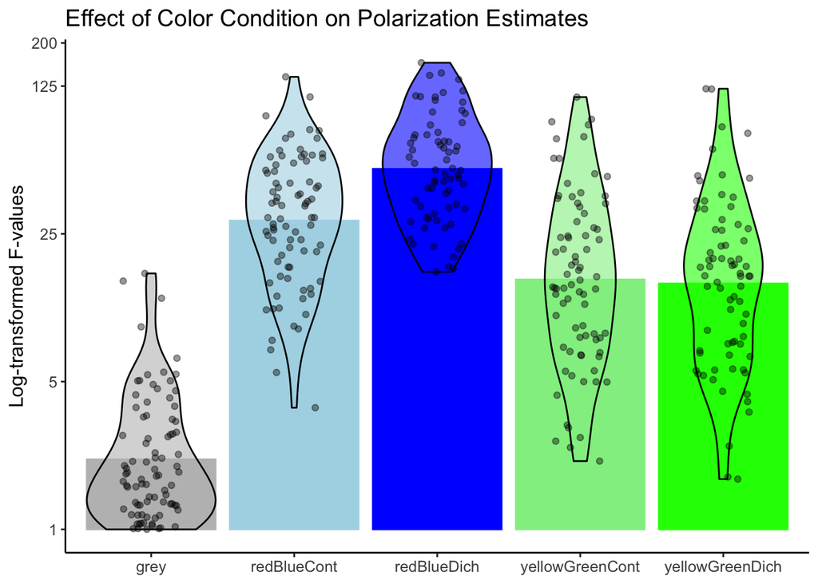

```r
# remove extreme F value outliers for the sake of the graph (+3 SDs)
dfPlot <-df[df$Fvalue<=mean(df$Fvalue,na.rm=T)+3*sd(df$Fvalue,na.rm=T),]
plotF <-ggplot(data=dfPlot,aes(x=colorCond,y=log(Fvalue+1),fill=colorCond,color=colorCond))+
  geom_bar(stat="summary",fun.y="mean", position="dodge")+
  geom_violin(stat="ydensity",position="dodge",color="black",alpha=.6)+
  geom_point(position=position_jitter(width=.2),alpha=.4,color="black",fill="black")+
  theme(text=element_text(size=12),axis.title.x=element_blank(),
        legend.position="none",panel.grid.major = element_blank(),
        panel.grid.minor = element_blank(),
        panel.background = element_blank(),
        axis.line = element_line(colour = "black"))+
  labs(title="Effect of Color Condition on Polarization Estimates")+
  ylab("Log-transformed F-values")+
  scale_fill_manual(values=rev(c("green","light green", "blue", "light blue", "grey")))+
  scale_color_manual(values=rev(c("green","light green", "blue", "light blue", "grey")))+
    scale_y_continuous(breaks=c(log(1),log(5),log(25),log(125),log(200)),labels=c(1,5,25,125,200))
plotF
```

# Task 2 data synthesis

### Study design

Participants’ color assignments transfer from Task 1 and they are randomly assigned to make judgments about either a Republican majority county or a Democratic majority county.

|  | Red/blue | Yellow/green | No color |
| --- | --- | --- | --- |
| Republican Majority | R majority (red) | R majority (yellow) | R majority (no color) |
| Democratic Majority | D majority (blue) | D majority (green) | D majority (no color) |

### Key parameters to update as study design changes

- **nParticipants**: Simulated sample size
- **experimentalConditions**: Vector of possible conditions (taken from the cells above).
- **conditionEffects**: *Relevant to data synthesis only.* Simulated average estimate for how likely the target is to vote Republican (vector in same order as experimentalConditions).

```r
#### DEFINE KEY PARAMETERS HERE ####
nParticipants=400 #set desired sample size
experimentalConditions=c("red_Rep","blue_Dem","yellow_Rep","green_Dem","grey_Rep","grey_Dem") #what are the experimental conditions?
conditionEffects=c(60,40,55,45,51,49) # what is the mean estimate for each of the above conditions?

#### Synthesize dataset ####
numConditions=seq(1,length(experimentalConditions),by=1) #how many conditions do we have?

df2 <- data.frame(subID=c(1:nParticipants)) # initial dataframe with subject IDs

for(participant in df2$subID){ #loop through the IDs

  #assign a condition
  thisCondNum <-sample(numConditions,size=1)
  df2[participant,"experimentalCond"]<-experimentalConditions[thisCondNum]

  # create a DV column and generate random response on our DV (which is percent likelihood that
  # the target will vote Republican). We'll use a SD of 10, which is arbitrary.
  df2[participant,"response"] <- as.integer(rnorm(1,mean=(conditionEffects[thisCondNum]),
                                  sd=10))

  }
```

### Synthetic data

```r
DT::datatable(df2, caption="Synthetic Task 2 Data")
```

|  | subID | experimentalCond | response |
| --- | --- | --- | --- |
| 1 | 1 | grey_Rep | 41 |
| 2 | 2 | grey_Rep | 54 |
| 3 | 3 | red_Rep | 59 |
| 4 | 4 | yellow_Rep | 57 |
| 5 | 5 | red_Rep | 66 |
| 6 | 6 | blue_Dem | 29 |
| 7 | 7 | green_Dem | 34 |
| 8 | 8 | green_Dem | 55 |
| 9 | 9 | yellow_Rep | 57 |
| 10 | 10 | blue_Dem | 48 |

[output cut: 390 more lines]

## Density plots of participants’ responses by condition

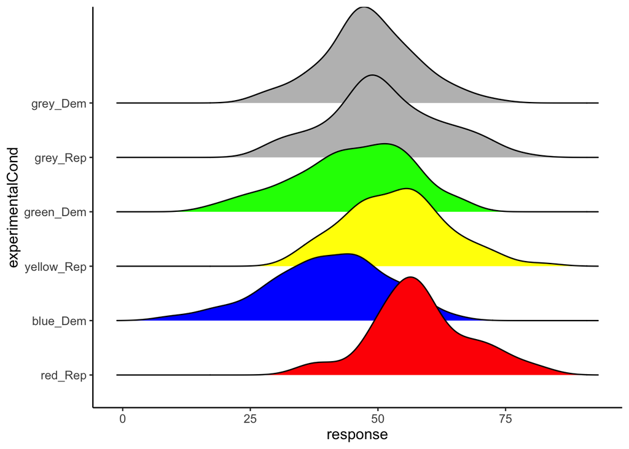

```r
df2$experimentalCond<-factor(df2$experimentalCond,levels=experimentalConditions)

plotTask2 <-ggplot(df2,aes(x=response,y=experimentalCond,fill=experimentalCond))+
    ggridges::stat_density_ridges()+
    scale_fill_manual(values=c("red","blue","yellow","green","grey","grey"))+
    theme(text=element_text(size=12),
        legend.position="none",panel.grid.major = element_blank(),
        panel.grid.minor = element_blank(),
        panel.background = element_blank(),
        axis.line = element_line(colour = "black"))


plotTask2
```

# Task 2 analyses

First we need to create separate color and political majority variables.

We’ll create a “colorCond” factor variable and a “majorityCond” where Dem= -.5 and Rep = .5.

```r
df2$colorCond<-as.factor(ifelse(grepl("red", df2$experimentalCond, fixed=TRUE)|grepl("blue", df2$experimentalCond, fixed=TRUE),"redBlue",
                        ifelse(grepl("yellow", df2$experimentalCond, fixed=TRUE)|grepl("green", df2$experimentalCond, fixed=TRUE),"yellowGreen","grey")))

df2$majorityCond <-ifelse(grepl("Dem",df2$experimentalCond,fixed=TRUE),-.5,
                          ifelse(grepl("Rep",df2$experimentalCond,fixed=TRUE),.5,NA))
```

In our central analysis for Task 2, we’ll use grey (no color) as the reference level for our colorCond factor. That way the main effect of majorityCond will be a manipulation/attention check that participants are noticing the numeric information presented on the map. Again, we will use modelAssumptions to visualize the residuals of the model and adjust the model or the variables as necessary. We will conduct parallel analyses with the participants’ ratings of *how important it is that the target vote* as the outcome variable. That variable was not simulated here.

```r
df2$colorCond<-relevel(df2$colorCond,ref="grey")
modTask2 <-lm(response~colorCond*majorityCond,data=df2)
summary(modTask2)
```

```
##
## Call:
## lm(formula = response ~ colorCond * majorityCond, data = df2)
##
## Residuals:
##     Min      1Q  Median      3Q     Max
## -30.259  -6.264  -0.421   6.722  28.480
##
## Coefficients:
##                                   Estimate Std. Error t value Pr(>|t|)
## (Intercept)                        49.6750     0.8336  59.589  < 2e-16 ***
## colorCondredBlue                   -0.3841     1.2741  -0.301   0.7632
## colorCondyellowGreen               -0.3384     1.2483  -0.271   0.7865
## majorityCond                        2.7945     1.6673   1.676   0.0945 .
## colorCondredBlue:majorityCond      15.2688     2.5481   5.992 4.68e-09 ***
## colorCondyellowGreen:majorityCond   5.5711     2.4965   2.232   0.0262 *
## ---
## Signif. codes:  0 '***' 0.001 '**' 0.01 '*' 0.05 '.' 0.1 ' ' 1
##
## Residual standard error: 10.35 on 394 degrees of freedom
## Multiple R-squared:  0.2199, Adjusted R-squared:   0.21
## F-statistic: 22.21 on 5 and 394 DF,  p-value: < 2.2e-16
```